# Trip data analytics

This analysis is based on the Divvy case study “‘Sophisticated, Clear, and Polished’: Divvy and Data Visualization” written by Kevin Hartman (found here: https://artscience.blog/home/divvy-dataviz-case-study). The purpose of this script is to consolidate downloaded Divvy data into a single dataframe and then conduct simple analysis to help answer the key question: “In what ways do members and casual riders use Divvy bikes differently?”

Install required packages

```r
library(tidyverse)
library(lubridate)
library(ggplot2)
getwd()
```

```
[1] "/cloud/project"
```

Read trip data set from csv

```r
tripdata_4 <- read_csv("202004-divvy-tripdata.csv")
tripdata_5 <- read_csv("202005-divvy-tripdata.csv")
tripdata_6 <- read_csv("202006-divvy-tripdata.csv")
```

Check column name

```r
colnames(tripdata_4)
```

```
 [1] "ride_id"            "rideable_type"      "started_at"         "ended_at"           "start_station_name" "start_station_id"   "end_station_name"
 [8] "end_station_id"     "start_lat"          "start_lng"          "end_lat"            "end_lng"            "member_casual"
```

```r
colnames(tripdata_5)
```

```
 [1] "ride_id"            "rideable_type"      "started_at"         "ended_at"           "start_station_name" "start_station_id"   "end_station_name"
 [8] "end_station_id"     "start_lat"          "start_lng"          "end_lat"            "end_lng"            "member_casual"
```

```r
colnames(tripdata_6)
```

```
 [1] "ride_id"            "rideable_type"      "started_at"         "ended_at"           "start_station_name" "start_station_id"   "end_station_name"
 [8] "end_station_id"     "start_lat"          "start_lng"          "end_lat"            "end_lng"            "member_casual"
```

Check Str

```r
str(tripdata_4)
```

```
spc_tbl_ [84,776 × 13] (S3: spec_tbl_df/tbl_df/tbl/data.frame)
 $ ride_id           : chr [1:84776] "A847FADBBC638E45" "5405B80E996FF60D" "5DD24A79A4E006F4" "2A59BBDF5CDBA725" ...
 $ rideable_type     : chr [1:84776] "docked_bike" "docked_bike" "docked_bike" "docked_bike" ...
 $ started_at        : POSIXct[1:84776], format: "2020-04-26 17:45:14" "2020-04-17 17:08:54" "2020-04-01 17:54:13" "2020-04-07 12:50:19" ...
 $ ended_at          : POSIXct[1:84776], format: "2020-04-26 18:12:03" "2020-04-17 17:17:03" "2020-04-01 18:08:36" "2020-04-07 13:02:31" ...
 $ start_station_name: chr [1:84776] "Eckhart Park" "Drake Ave & Fullerton Ave" "McClurg Ct & Erie St" "California Ave & Division St" ...
 $ start_station_id  : num [1:84776] 86 503 142 216 125 173 35 434 627 377 ...
 $ end_station_name  : chr [1:84776] "Lincoln Ave & Diversey Pkwy" "Kosciuszko Park" "Indiana Ave & Roosevelt Rd" "Wood St & Augusta Blvd" ...
 $ end_station_id    : num [1:84776] 152 499 255 657 323 35 635 382 359 508 ...
 $ start_lat         : num [1:84776] 41.9 41.9 41.9 41.9 41.9 ...
 $ start_lng         : num [1:84776] -87.7 -87.7 -87.6 -87.7 -87.6 ...
 $ end_lat           : num [1:84776] 41.9 41.9 41.9 41.9 42 ...
 $ end_lng           : num [1:84776] -87.7 -87.7 -87.6 -87.7 -87.7 ...
 $ member_casual     : chr [1:84776] "member" "member" "member" "member" ...
 - attr(*, "spec")=
  .. cols(
  ..   ride_id = col_character(),
  ..   rideable_type = col_character(),
  ..   started_at = col_datetime(format = ""),
  ..   ended_at = col_datetime(format = ""),
  ..   start_station_name = col_character(),
  ..   start_station_id = col_double(),
  ..   end_station_name = col_character(),
  ..   end_station_id = col_double(),
  ..   start_lat = col_double(),
  ..   start_lng = col_double(),
  ..   end_lat = col_double(),
  ..   end_lng = col_double(),
  ..   member_casual = col_character()
  .. )
 - attr(*, "problems")=<externalptr>
```

```r
str(tripdata_5)
```

```
spc_tbl_ [200,274 × 13] (S3: spec_tbl_df/tbl_df/tbl/data.frame)
 $ ride_id           : chr [1:200274] "02668AD35674B983" "7A50CCAF1EDDB28F" "2FFCDFDB91FE9A52" "58991CF1DB75BA84" ...
 $ rideable_type     : chr [1:200274] "docked_bike" "docked_bike" "docked_bike" "docked_bike" ...
 $ started_at        : POSIXct[1:200274], format: "2020-05-27 10:03:52" "2020-05-25 10:47:11" "2020-05-02 14:11:03" "2020-05-02 16:25:36" ...
 $ ended_at          : POSIXct[1:200274], format: "2020-05-27 10:16:49" "2020-05-25 11:05:40" "2020-05-02 15:48:21" "2020-05-02 16:39:28" ...
 $ start_station_name: chr [1:200274] "Franklin St & Jackson Blvd" "Clark St & Wrightwood Ave" "Kedzie Ave & Milwaukee Ave" "Clarendon Ave & Leland Ave" ...
 $ start_station_id  : num [1:200274] 36 340 260 251 261 206 261 180 331 219 ...
 $ end_station_name  : chr [1:200274] "Wabash Ave & Grand Ave" "Clark St & Leland Ave" "Kedzie Ave & Milwaukee Ave" "Lake Shore Dr & Wellington Ave" ...
 $ end_station_id    : num [1:200274] 199 326 260 157 206 22 261 180 300 305 ...
 $ start_lat         : num [1:200274] 41.9 41.9 41.9 42 41.9 ...
 $ start_lng         : num [1:200274] -87.6 -87.6 -87.7 -87.7 -87.7 ...
 $ end_lat           : num [1:200274] 41.9 42 41.9 41.9 41.8 ...
 $ end_lng           : num [1:200274] -87.6 -87.7 -87.7 -87.6 -87.6 ...
 $ member_casual     : chr [1:200274] "member" "casual" "casual" "casual" ...
 - attr(*, "spec")=
  .. cols(
  ..   ride_id = col_character(),
  ..   rideable_type = col_character(),
  ..   started_at = col_datetime(format = ""),
  ..   ended_at = col_datetime(format = ""),
  ..   start_station_name = col_character(),
  ..   start_station_id = col_double(),
  ..   end_station_name = col_character(),
  ..   end_station_id = col_double(),
  ..   start_lat = col_double(),
  ..   start_lng = col_double(),
  ..   end_lat = col_double(),
  ..   end_lng = col_double(),
  ..   member_casual = col_character()
  .. )
 - attr(*, "problems")=<externalptr>
```

```r
str(tripdata_6)
```

```
spc_tbl_ [343,005 × 13] (S3: spec_tbl_df/tbl_df/tbl/data.frame)
 $ ride_id           : chr [1:343005] "8CD5DE2C2B6C4CFC" "9A191EB2C751D85D" "F37D14B0B5659BCF" "C41237B506E85FA1" ...
 $ rideable_type     : chr [1:343005] "docked_bike" "docked_bike" "docked_bike" "docked_bike" ...
 $ started_at        : POSIXct[1:343005], format: "2020-06-13 23:24:48" "2020-06-26 07:26:10" "2020-06-23 17:12:41" "2020-06-20 01:09:35" ...
 $ ended_at          : POSIXct[1:343005], format: "2020-06-13 23:36:55" "2020-06-26 07:31:58" "2020-06-23 17:21:14" "2020-06-20 01:28:24" ...
 $ start_station_name: chr [1:343005] "Wilton Ave & Belmont Ave" "Federal St & Polk St" "Daley Center Plaza" "Broadway & Cornelia Ave" ...
 $ start_station_id  : num [1:343005] 117 41 81 303 327 327 41 115 338 84 ...
 $ end_station_name  : chr [1:343005] "Damen Ave & Clybourn Ave" "Daley Center Plaza" "State St & Harrison St" "Broadway & Berwyn Ave" ...
 $ end_station_id    : num [1:343005] 163 81 5 294 117 117 81 303 164 53 ...
 $ start_lat         : num [1:343005] 41.9 41.9 41.9 41.9 41.9 ...
 $ start_lng         : num [1:343005] -87.7 -87.6 -87.6 -87.6 -87.7 ...
 $ end_lat           : num [1:343005] 41.9 41.9 41.9 42 41.9 ...
 $ end_lng           : num [1:343005] -87.7 -87.6 -87.6 -87.7 -87.7 ...
 $ member_casual     : chr [1:343005] "casual" "member" "member" "casual" ...
 - attr(*, "spec")=
  .. cols(
  ..   ride_id = col_character(),
  ..   rideable_type = col_character(),
  ..   started_at = col_datetime(format = ""),
  ..   ended_at = col_datetime(format = ""),
  ..   start_station_name = col_character(),
  ..   start_station_id = col_double(),
  ..   end_station_name = col_character(),
  ..   end_station_id = col_double(),
  ..   start_lat = col_double(),
  ..   start_lng = col_double(),
  ..   end_lat = col_double(),
  ..   end_lng = col_double(),
  ..   member_casual = col_character()
  .. )
 - attr(*, "problems")=<externalptr>
```

Combine into single file

```r
all_trips <- bind_rows(tripdata_4, tripdata_5, tripdata_6)
all_trips <- all_trips %>%
  select(-c(start_lat, start_lng, end_lat, end_lng))
```

Inspect the combined table

```r
colnames(all_trips)
```

```
[1] "ride_id"            "rideable_type"      "started_at"         "ended_at"           "start_station_name" "start_station_id"   "end_station_name"
[8] "end_station_id"     "member_casual"
```

```r
nrow(all_trips)
```

```
[1] 628055
```

```r
dim(all_trips)
```

```
[1] 628055      9
```

```r
head(all_trips)
```

| ride_id | rideable_type | started_at | ended_at | start_station_name | start_station_id | end_station_name | end_station_id | member_casual |
| --- | --- | --- | --- | --- | --- | --- | --- | --- |
| A847FADBBC638E45 | docked_bike | 2020-04-26 17:45:14 | 2020-04-26 18:12:03 | Eckhart Park | 86 | Lincoln Ave & Diversey Pkwy | 152 | member |
| 5405B80E996FF60D | docked_bike | 2020-04-17 17:08:54 | 2020-04-17 17:17:03 | Drake Ave & Fullerton Ave | 503 | Kosciuszko Park | 499 | member |
| 5DD24A79A4E006F4 | docked_bike | 2020-04-01 17:54:13 | 2020-04-01 18:08:36 | McClurg Ct & Erie St | 142 | Indiana Ave & Roosevelt Rd | 255 | member |
| 2A59BBDF5CDBA725 | docked_bike | 2020-04-07 12:50:19 | 2020-04-07 13:02:31 | California Ave & Division St | 216 | Wood St & Augusta Blvd | 657 | member |
| 27AD306C119C6158 | docked_bike | 2020-04-18 10:22:59 | 2020-04-18 11:15:54 | Rush St & Hubbard St | 125 | Sheridan Rd & Lawrence Ave | 323 | casual |
| 356216E875132F61 | docked_bike | 2020-04-30 17:55:47 | 2020-04-30 18:01:11 | Mies van der Rohe Way & Chicago Ave | 173 | Streeter Dr & Grand Ave | 35 | member |

```r
str(all_trips)
```

```
tibble [628,055 × 9] (S3: tbl_df/tbl/data.frame)
 $ ride_id           : chr [1:628055] "A847FADBBC638E45" "5405B80E996FF60D" "5DD24A79A4E006F4" "2A59BBDF5CDBA725" ...
 $ rideable_type     : chr [1:628055] "docked_bike" "docked_bike" "docked_bike" "docked_bike" ...
 $ started_at        : POSIXct[1:628055], format: "2020-04-26 17:45:14" "2020-04-17 17:08:54" "2020-04-01 17:54:13" "2020-04-07 12:50:19" ...
 $ ended_at          : POSIXct[1:628055], format: "2020-04-26 18:12:03" "2020-04-17 17:17:03" "2020-04-01 18:08:36" "2020-04-07 13:02:31" ...
 $ start_station_name: chr [1:628055] "Eckhart Park" "Drake Ave & Fullerton Ave" "McClurg Ct & Erie St" "California Ave & Division St" ...
 $ start_station_id  : num [1:628055] 86 503 142 216 125 173 35 434 627 377 ...
 $ end_station_name  : chr [1:628055] "Lincoln Ave & Diversey Pkwy" "Kosciuszko Park" "Indiana Ave & Roosevelt Rd" "Wood St & Augusta Blvd" ...
 $ end_station_id    : num [1:628055] 152 499 255 657 323 35 635 382 359 508 ...
 $ member_casual     : chr [1:628055] "member" "member" "member" "member" ...
```

```r
summary(all_trips)
```

```
   ride_id          rideable_type        started_at                        ended_at                      start_station_name start_station_id
 Length:628055      Length:628055      Min.   :2020-04-01 00:00:30.00   Min.   :2020-04-01 00:10:45.00   Length:628055      Min.   :  2
 Class :character   Class :character   1st Qu.:2020-05-15 16:55:37.50   1st Qu.:2020-05-15 17:25:06.00   Class :character   1st Qu.:110
 Mode  :character   Mode  :character   Median :2020-06-06 13:45:59.00   Median :2020-06-06 14:18:45.00   Mode  :character   Median :208
                                       Mean   :2020-05-30 22:39:16.75   Mean   :2020-05-30 23:13:05.18                      Mean   :230
                                       3rd Qu.:2020-06-19 17:19:09.00   3rd Qu.:2020-06-19 17:44:20.50                      3rd Qu.:317
                                       Max.   :2020-06-30 23:59:54.00   Max.   :2020-07-03 20:26:15.00                      Max.   :673

 end_station_name   end_station_id  member_casual
 Length:628055      Min.   :  2.0   Length:628055
 Class :character   1st Qu.:110.0   Class :character
 Mode  :character   Median :210.0   Mode  :character
                    Mean   :231.6
                    3rd Qu.:319.0
                    Max.   :674.0
                    NA's   :888
```

Extract date, month, day, year

```r
all_trips$date <- as.Date(all_trips$started_at)
all_trips$month <- format(as.Date(all_trips$date), "%m")
all_trips$day <- format(as.Date(all_trips$date), "%d")
all_trips$year <- format(as.Date(all_trips$date), "%Y")
all_trips$day_of_week <- format(as.Date(all_trips$date), "%A")
```

Add ride_length

```r
all_trips$ride_length <- difftime(all_trips$ended_at, all_trips$started_at)
str(all_trips)
```

```
tibble [628,055 × 15] (S3: tbl_df/tbl/data.frame)
 $ ride_id           : chr [1:628055] "A847FADBBC638E45" "5405B80E996FF60D" "5DD24A79A4E006F4" "2A59BBDF5CDBA725" ...
 $ rideable_type     : chr [1:628055] "docked_bike" "docked_bike" "docked_bike" "docked_bike" ...
 $ started_at        : POSIXct[1:628055], format: "2020-04-26 17:45:14" "2020-04-17 17:08:54" "2020-04-01 17:54:13" "2020-04-07 12:50:19" ...
 $ ended_at          : POSIXct[1:628055], format: "2020-04-26 18:12:03" "2020-04-17 17:17:03" "2020-04-01 18:08:36" "2020-04-07 13:02:31" ...
 $ start_station_name: chr [1:628055] "Eckhart Park" "Drake Ave & Fullerton Ave" "McClurg Ct & Erie St" "California Ave & Division St" ...
 $ start_station_id  : num [1:628055] 86 503 142 216 125 173 35 434 627 377 ...
 $ end_station_name  : chr [1:628055] "Lincoln Ave & Diversey Pkwy" "Kosciuszko Park" "Indiana Ave & Roosevelt Rd" "Wood St & Augusta Blvd" ...
 $ end_station_id    : num [1:628055] 152 499 255 657 323 35 635 382 359 508 ...
 $ member_casual     : chr [1:628055] "member" "member" "member" "member" ...
 $ date              : Date[1:628055], format: "2020-04-26" "2020-04-17" "2020-04-01" "2020-04-07" ...
 $ month             : chr [1:628055] "04" "04" "04" "04" ...
 $ day               : chr [1:628055] "26" "17" "01" "07" ...
 $ year              : chr [1:628055] "2020" "2020" "2020" "2020" ...
 $ day_of_week       : chr [1:628055] "Sunday" "Friday" "Wednesday" "Tuesday" ...
 $ ride_length       : 'difftime' num [1:628055] 1609 489 863 732 ...
  ..- attr(*, "units")= chr "secs"
```

Convert ride_length to numeric

```r
all_trips$ride_length <- as.numeric(as.character(all_trips$ride_length))
is.numeric(all_trips$ride_length)
```

```
[1] TRUE
```

Delete rows which have nagative ride_length

```r
all_trips_v2 <- all_trips[!(all_trips$ride_length < 0),]
```

Calc mean, median, max, min of ride_length

```r
summary(all_trips_v2$ride_length)
```

```
   Min. 1st Qu.  Median    Mean 3rd Qu.    Max.
      0     605    1100    2031    1858 3523202
```

Compare members and casual users

```r
aggregate(all_trips_v2$ride_length ~ all_trips_v2$member_casual, FUN = mean)
```

| all_trips_v2$member_casual | all_trips_v2$ride_length |
| --- | --- |
| casual | 3205.879 |
| member | 1171.216 |

```r
aggregate(all_trips_v2$ride_length ~ all_trips_v2$member_casual, FUN = median)
```

| all_trips_v2$member_casual | all_trips_v2$ride_length |
| --- | --- |
| casual | 1523 |
| member | 870 |

```r
aggregate(all_trips_v2$ride_length ~ all_trips_v2$member_casual, FUN = max)
```

| all_trips_v2$member_casual | all_trips_v2$ride_length |
| --- | --- |
| casual | 3341033 |
| member | 3523202 |

```r
aggregate(all_trips_v2$ride_length ~ all_trips_v2$member_casual, FUN = min)
```

| all_trips_v2$member_casual | all_trips_v2$ride_length |
| --- | --- |
| casual | 0 |
| member | 0 |

See the average ride time by each day for members vs casuals

```r
aggregate(all_trips_v2$ride_length ~ all_trips_v2$member_casual + all_trips_v2$day_of_week, FUN = mean)
```

| all_trips_v2$member_casual | all_trips_v2$day_of_week | all_trips_v2$ride_length |
| --- | --- | --- |
| casual | Friday | 3242.472 |
| member | Friday | 1105.316 |
| casual | Monday | 3244.295 |
| member | Monday | 1073.133 |
| casual | Saturday | 3083.580 |
| member | Saturday | 1297.472 |
| casual | Sunday | 3369.782 |
| member | Sunday | 1306.823 |
| casual | Thursday | 3484.582 |
| member | Thursday | 1120.197 |

[output cut: 4 more lines]

```r
#all_trips_v2$day_of_week <- ordered(all_trips_v2$day_of_week, levels=1:7, labels=c("Sunday", "Monday", "Tuesday", "Wednesday", "Thursday", "Friday", "Saturday"))
str(all_trips_v2)
```

```
tibble [627,363 × 15] (S3: tbl_df/tbl/data.frame)
 $ ride_id           : chr [1:627363] "A847FADBBC638E45" "5405B80E996FF60D" "5DD24A79A4E006F4" "2A59BBDF5CDBA725" ...
 $ rideable_type     : chr [1:627363] "docked_bike" "docked_bike" "docked_bike" "docked_bike" ...
 $ started_at        : POSIXct[1:627363], format: "2020-04-26 17:45:14" "2020-04-17 17:08:54" "2020-04-01 17:54:13" "2020-04-07 12:50:19" ...
 $ ended_at          : POSIXct[1:627363], format: "2020-04-26 18:12:03" "2020-04-17 17:17:03" "2020-04-01 18:08:36" "2020-04-07 13:02:31" ...
 $ start_station_name: chr [1:627363] "Eckhart Park" "Drake Ave & Fullerton Ave" "McClurg Ct & Erie St" "California Ave & Division St" ...
 $ start_station_id  : num [1:627363] 86 503 142 216 125 173 35 434 627 377 ...
 $ end_station_name  : chr [1:627363] "Lincoln Ave & Diversey Pkwy" "Kosciuszko Park" "Indiana Ave & Roosevelt Rd" "Wood St & Augusta Blvd" ...
 $ end_station_id    : num [1:627363] 152 499 255 657 323 35 635 382 359 508 ...
 $ member_casual     : chr [1:627363] "member" "member" "member" "member" ...
 $ date              : Date[1:627363], format: "2020-04-26" "2020-04-17" "2020-04-01" "2020-04-07" ...
 $ month             : chr [1:627363] "04" "04" "04" "04" ...
 $ day               : chr [1:627363] "26" "17" "01" "07" ...
 $ year              : chr [1:627363] "2020" "2020" "2020" "2020" ...
 $ day_of_week       : chr [1:627363] "Sunday" "Friday" "Wednesday" "Tuesday" ...
 $ ride_length       : num [1:627363] 1609 489 863 732 3175 ...
```

calculate the average ride time by each day for members vs casual again

```r
aggregate(all_trips_v2$ride_length ~ all_trips_v2$member_casual + all_trips_v2$day_of_week, FUN = mean)
```

| all_trips_v2$member_casual | all_trips_v2$day_of_week | all_trips_v2$ride_length |
| --- | --- | --- |
| casual | Friday | 3242.472 |
| member | Friday | 1105.316 |
| casual | Monday | 3244.295 |
| member | Monday | 1073.133 |
| casual | Saturday | 3083.580 |
| member | Saturday | 1297.472 |
| casual | Sunday | 3369.782 |
| member | Sunday | 1306.823 |
| casual | Thursday | 3484.582 |
| member | Thursday | 1120.197 |

[output cut: 4 more lines]

analyze ridership data by type and weekday

```r
all_trips_v2 %>%
  mutate(weekday = wday(started_at, label = TRUE)) %>%
  group_by(member_casual, weekday) %>%
  summarize(number_of_ride = n(), average_duration = mean(ride_length)) %>%
  arrange(member_casual, weekday)
```

| member_casual | weekday | number_of_ride | average_duration |
| --- | --- | --- | --- |
| casual | Sun | 52497 | 3369.782 |
| casual | Mon | 27563 | 3244.295 |
| casual | Tue | 28375 | 3114.844 |
| casual | Wed | 26896 | 2873.052 |
| casual | Thu | 30732 | 3484.582 |
| casual | Fri | 34029 | 3242.472 |
| casual | Sat | 64913 | 3083.580 |
| member | Sun | 54867 | 1306.823 |
| member | Mon | 43698 | 1073.133 |
| member | Tue | 47578 | 1104.028 |

[output cut: 4 more lines]

Visualize the number of rises by rider type

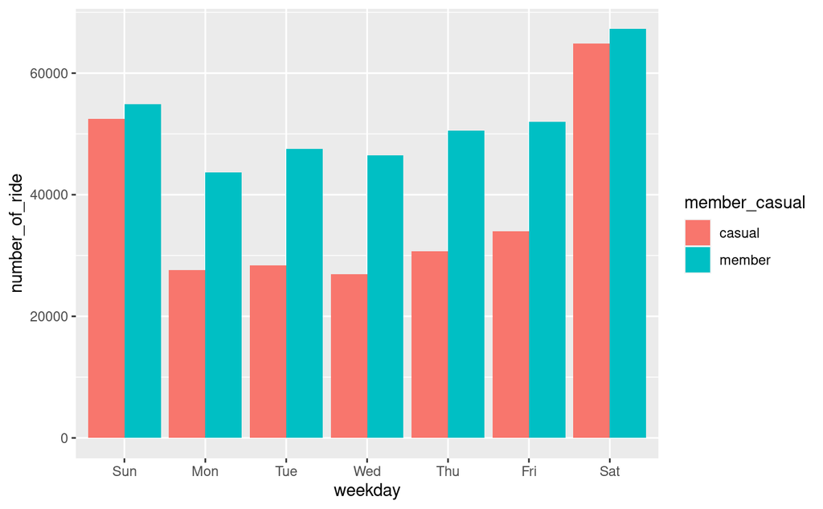

```r
all_trips_v2 %>%
  mutate(weekday = wday(started_at, label = TRUE)) %>%
  group_by(member_casual, weekday) %>%
  summarize(number_of_ride = n(), average_duration = mean(ride_length)) %>%
  arrange(member_casual, weekday) %>%
  ggplot(aes(x = weekday, y = number_of_ride, fill = member_casual)) +
  geom_col(position = "dodge")
```

```r
NA
```

Visualize average_duration by rider_type

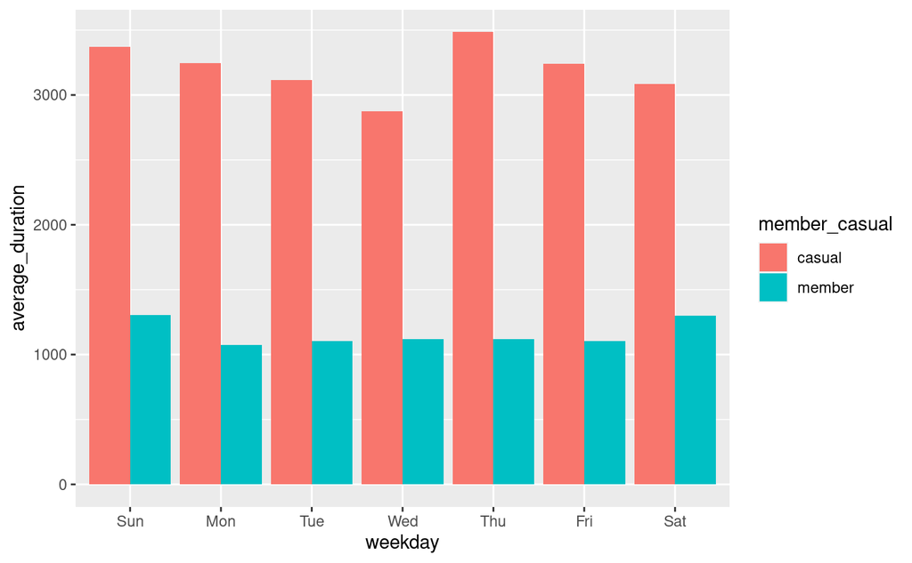

```r
all_trips_v2 %>%
  mutate(weekday = wday(started_at, label = TRUE)) %>%
  group_by(member_casual, weekday) %>%
  summarise(number_of_rides = n()
            ,average_duration = mean(ride_length)) %>%
  arrange(member_casual, weekday)  %>%
  ggplot(aes(x = weekday, y = average_duration, fill = member_casual)) +
  geom_col(position = "dodge")
```

Export summary file to csv

```r
counts <- all_trips_v2 %>%
  mutate(weekday = wday(started_at, label = TRUE)) %>%
  group_by(member_casual, weekday) %>%
  summarize(number_of_ride = n(), average_duration = mean(ride_length)) %>%
  arrange(member_casual, weekday)
write.csv(counts, file = 'tripdate_output_summary.csv')
```